# Tarea III

Rayan García Fabián 144424, Bernardo Mondragon Brozon 143743

1 October 2018

# Problema 1

Un estadístico está interesado en el número N de peces en un estanque. El captura 250 peces, los marca y los regresa al estanque. Unos cuantos días después regresa y atrapa peces hasta que obtiene 50 peces marcados, en ese punto también tiene 124 peces no marcados (la muestra total es de 174 peces). *¿Cuál es la estimación de N?* Haga un programa, que permita simular el proceso de obtener la primera y segunda muestra considerando como parámetros el tamaño $N$ de la población de interés, el tamaño de la primera y segunda muestra y como datos a estimar son: de qué tamaño debe ser $n_1$ y $n_2$ para obtener una buena aproximación y ver cómo se afecta por el tamaño $N$.

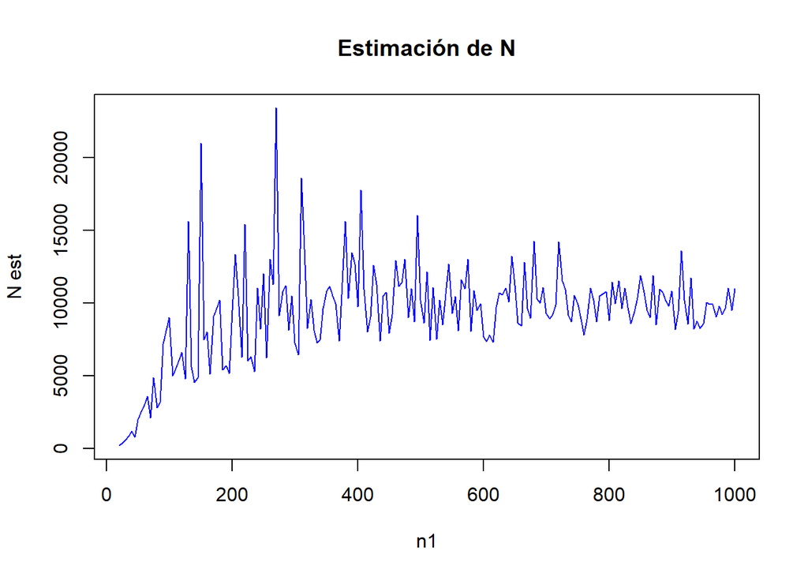

```r
Simulacion_Peces<-function(N,n1,n2){ #Función para simular el proceso de obtener la primera y segunda muestra
  pecesM<-c(rep("M",n1))
  pecesT<-c(pecesM,c(rep("NM",N-n1)))
  muestra2<-sample(pecesT,n2)
  r<-length(subset(muestra2,muestra2=="M"))
  N_est<-(n1*n2)/(r+1) #Ojo aquí consideramos r+1 ya que como no asignamos probabilidades a la muestra, se van a dar casos en los que r=0.
  return(N_est)
}

#Supongamos N=10000, vamos a ver de qué tamaño deben ser n1 y n2 para obtener una buena estimación de N. Además supondremos que n1>n2
N<-10000
n1<-c(seq(20,1000,by=5))
n2<-c(seq(10,990,by=5))

M_est<-c()
for (i in 1:length(n1)){
  M_est[i]<-Simulacion_Peces(N,n1[[i]],n2[[i]])
}

plot(n1[1:length(n1)],M_est[1:length(n1)],type = "l",col="blue",main = "Estimación de N", xlab = "n1",ylab = "N est")
```

# Problema 2

$$F_{X}=\int_{0}^{x} \frac{\alpha\beta^{\alpha}}{(s+\beta)^{\alpha+1}}ds=\alpha\beta^{\alpha}\int_{0}^{x} \frac{1}{(+\beta)^{\alpha+1}}ds=\alpha\beta^{\alpha}\int_{\beta}^{\beta+x} \frac{1}{u^{\alpha+1}}du\\
=\alpha\beta^{\alpha} \left( \frac{-u^{-\alpha}}{\alpha}\right) \Big|_{\beta}^{\beta+x} = 1-\left(\frac{\beta}{\beta+x}\right)^\alpha$$

Para el cálculo de la esperanza notemos que X es una v.a no negativa, entonces se puede proceder de manera más sencilla por medio de la función de supervivencia $S(x)=1-F_{X}(x)$
$$E[X]=\int_{0}^{\infty}x(1-F_{X}(x))dx=\int_{0}^{\infty}\frac{\beta^{\alpha}}{(x+\beta)^{\alpha}}dx=\frac{\beta}{\alpha-1}$$

De manera alternativa podemos considerar a Y distribuida Pareto del tipo I, sabemos que $E[Y]=\frac{\alpha\beta}{\alpha-1}$. Entonces sea $X=Y-\beta$, se tiene que $E[X]=E[Y]-\beta=\frac{\alpha\beta}{\alpha-1}-\beta$.

Partiendo de la transformación anterior se tiene que $Var(X)=Var(Y)=\frac{\alpha^{2}}{(\alpha-1)^{2}(\alpha-2)}; \alpha>2$.

Ahora obtendremos por medio de simulación una muestra de X y su función de distribución

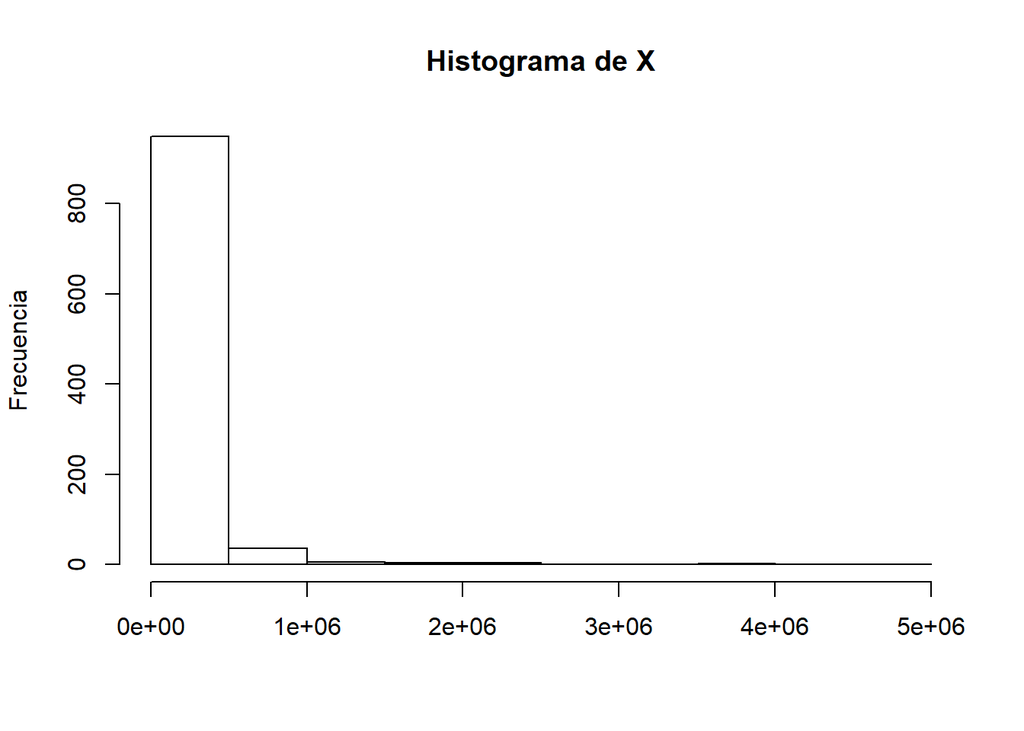

```r
Pareto_Lomax<-function(a,b,n){
  u<-runif(n)
  Lomax_MA<-c()
  for (i in 1:n) {
  Lomax_MA[i]<-(b*(1-(1-u[[i]])^(1/a)))/((1-u[[i]])^(1/a))
  }
  return(Lomax_MA)
}

hist(Pareto_Lomax(2,125000,1000),main = "Histograma de X",xlab = "",ylab = "Frecuencia")
```

Realizamos la simulación de los activos de la compañía en un horizonte de cinco años.S upondremos además que la aseguradora siempre renueva la póliza con el cliente, esto es que una vez que un cliente reclama se le vuelve a vender la póliza al año siguiente.

```r
registro<-function(activos,prima,n_clientes,prob_reclamo){
registro_activos<-c()
registro_activos[1]<-activos
for (i in 2:6) {
reclamos<-rbinom(n_clientes,1,prob_reclamo)
monto_reclamos<-Pareto_Lomax(5,125000,sum(reclamos))
registro_activos[i]<-registro_activos[i-1]-sum(monto_reclamos)+n_clientes*prima
if(registro_activos[i-1]<=0){
  registro_activos[i]<-0
  }
}
return(registro_activos)
}

activos<-10e6
prima<-5500
n_clientes<-1000
prob_reclamo<-0.1

huella<-matrix(,100,6)
for (i in 1:100) {
  huella[i,]<-registro(activos =activos, prima = prima, n_clientes = n_clientes,prob_reclamo = prob_reclamo)
}

colnames(huella)<-c("z(0)","z(1)","z(2)","z(3)","z(4)","z(5)")
huella<-as.data.frame(huella)
head(huella)
```

```
##    z(0)     z(1)     z(2)     z(3)     z(4)     z(5)
## 1 1e+07 12730690 14235029 16509835 19442149 21649759
## 2 1e+07 12506967 15361069 18284455 20408907 22408325
## 3 1e+07 12419670 14378746 17264922 20441961 23593476
## 4 1e+07 12738021 16024544 17985620 20578596 22413798
## 5 1e+07 12355410 14470563 17601073 20028390 22420535
## 6 1e+07 12804441 15810716 17797649 20883141 23318152
```

Notemos que hasta el momento no hemos visto ningún caso de ruina. Estudiemos un esquema en el que si el registro de activos en el periodo excede cierta cantidad, entonces se recompensa a los accionistas.

```r
registro_acc<-function(activos,prima,n_clientes,prob_reclamo){
registro_activos<-c()
registro_activos[1]<-activos
for (i in 2:6) {
reclamos<-rbinom(n_clientes,1,prob_reclamo)
monto_reclamos<-Pareto_Lomax(5,125000,sum(reclamos))
if(registro_activos[i-1]<=0){
  registro_activos[i:6]<-0
}
else if(registro_activos[i-1]>1000000){
registro_activos[i]<-registro_activos[i-1]-(10e6)-sum(monto_reclamos)+n_clientes*prima
}
else{registro_activos[i]<-registro_activos[i-1]-sum(monto_reclamos)+n_clientes*prima
}
}
return(registro_activos)
}

activos<-10e6
prima<-5500
n_clientes<-1000
prob_reclamo<-0.1

huella<-matrix(,100,6)
for (i in 1:100) {
  huella[i,]<-registro_acc(activos =activos, prima = prima, n_clientes = n_clientes,prob_reclamo = prob_reclamo)
}

colnames(huella)<-c("z(0)","z(1)","z(2)","z(3)","z(4)","z(5)")
huella<-as.data.frame(huella)
head(huella)
```

```
##    z(0)    z(1)     z(2) z(3) z(4) z(5)
## 1 1e+07 2266959 -6094866    0    0    0
## 2 1e+07 1423062 -5734089    0    0    0
## 3 1e+07 2485387 -4573133    0    0    0
## 4 1e+07 3379089 -3300119    0    0    0
## 5 1e+07 1209229 -7847811    0    0    0
## 6 1e+07 2888244 -5519282    0    0    0
```

Notemos que bajo este esquema en el que los accionistas son recompensados, la probabilidad de quiebra es 1.

# Problema 3

Proponer algoritmos (método y pseudocódigo o código, así como una corrida) para generar muestras de las siguientes densidades.

*Cauchy $f(x)=\frac{1}{\pi\beta\left[1+(\frac{x-\gamma}{\beta})^2\right]}; \gamma,x\in \mathbb{R}; \beta>0$

Podemos encontrar la distribución de X como $F_X(x)=\frac{arctan(\frac{x-\gamma}{\beta})}{\pi}+\frac{1}{2}$, entonces $F^{-1}(u)=tan(\pi(u-\frac{1}{2}))$. Usamos el método de la transformada inversa

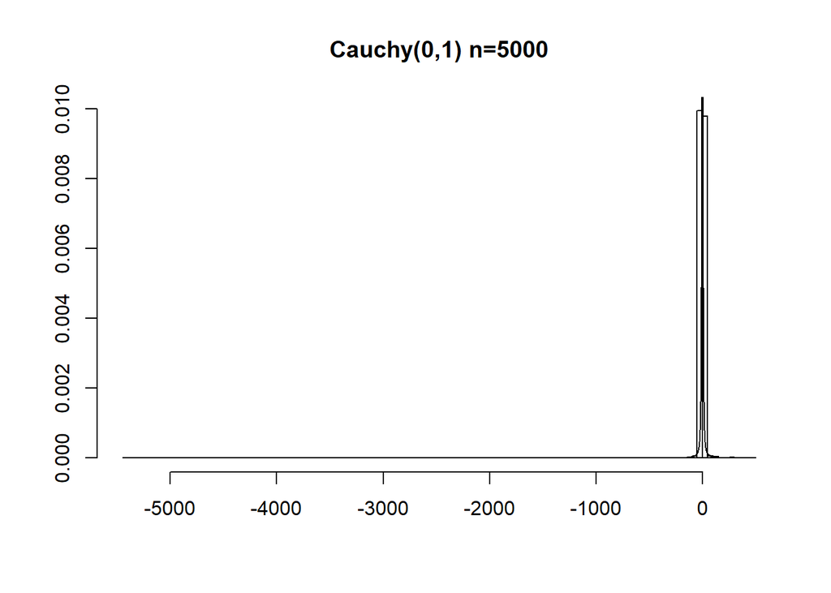

```r
cauchy<-function(gamma,beta,n){
u<-runif(n)
u<-tan(pi*u)*beta+gamma
return(u)
}
x<-1:100
hist(cauchy(0,1,5000),probability=T,breaks=100,main = "Cauchy(0,1) n=5000",ylab = "",xlab = "")
curve(dcauchy(x),add=T,from=-100,to=100)
```

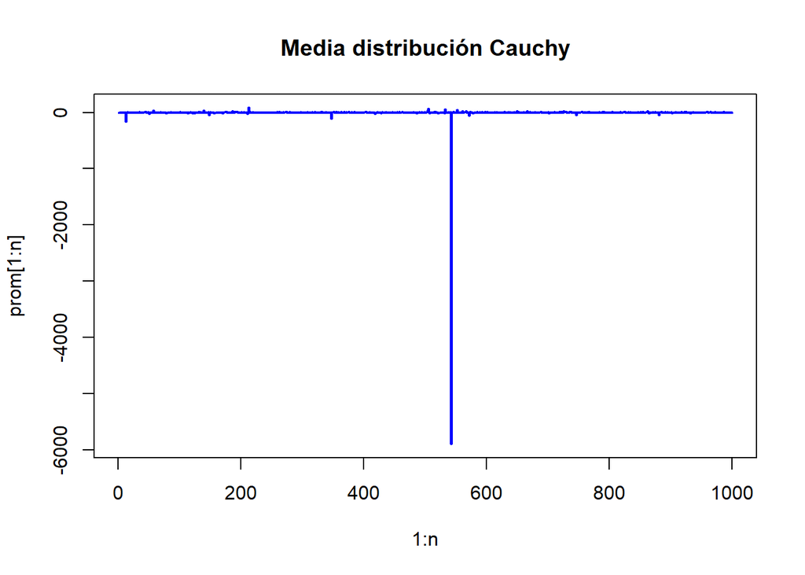

```r
U<- numeric(1000)
n<-1000
prom<-numeric(n)
y<-c()
for (i in 1:n) {
  u<-runif(1000)
  x<-tan(pi*(u-0.5))
  prom[i]<-mean(x)
}
plot(1:n,prom[1:n],type="l",lwd=2,col="blue",main = "Media distribución Cauchy")
```

*Gumbel $f(x)=\frac{1}{\beta} exp\left[-e^{-\frac{(x-\gamma)}{\beta}}-\frac{x-\gamma}{\beta}\right]}; \gamma,x\in \mathbb{R}; \beta>0$.

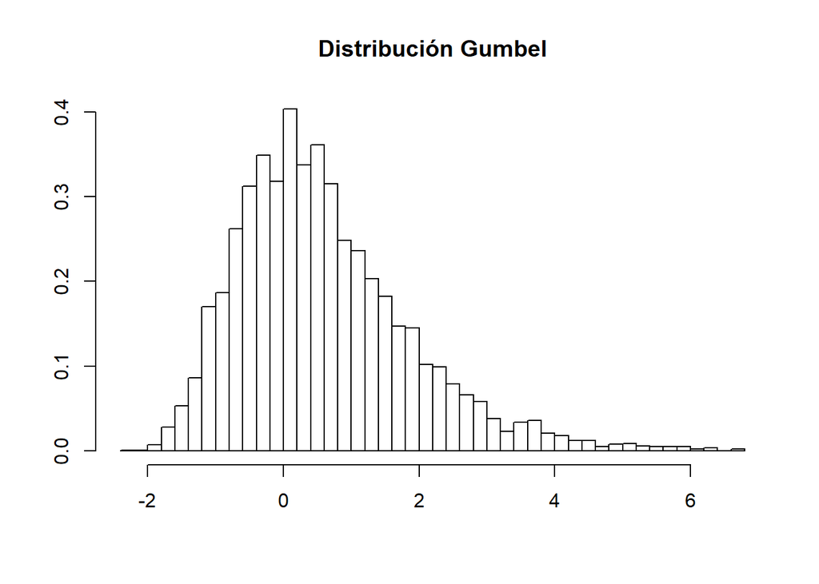

```r
gumbel<-function(gamma,beta,n){
unif<-runif(n)
unif<--beta*log(-log(unif))+gamma
return(unif)
}
hist(gumbel(0,1,5000),probability =T,breaks=60,xlab = "",ylab="",main = "Distribución Gumbel")
```

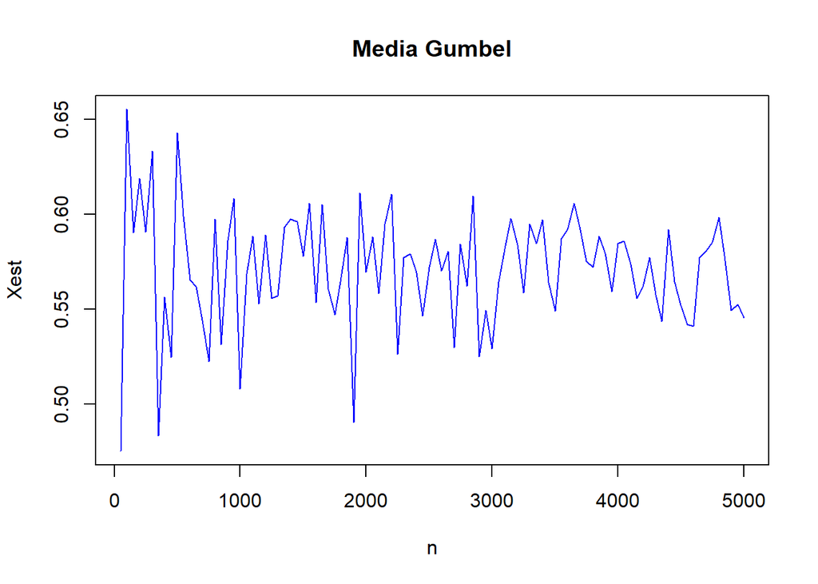

```r
n_s<-c(seq(50,5000,by=50))
X_est<-c()
for (i in 1:length(n_s)) {
  X_est[i]<-sum(gumbel(0,1,n_s[i]))/n_s[i]
}

plot(n_s[1:length(n_s)],X_est[1:length(n_s)],type = "l",col="blue", xlab = "n",ylab = "Xest",main="Media Gumbel")
```

Para esto utilizaremos el hecho de que si $X\sim U(0,1)$, entonces $\gamma+\beta(log(X)-(1-X))\sim log(\gamma,\beta)$

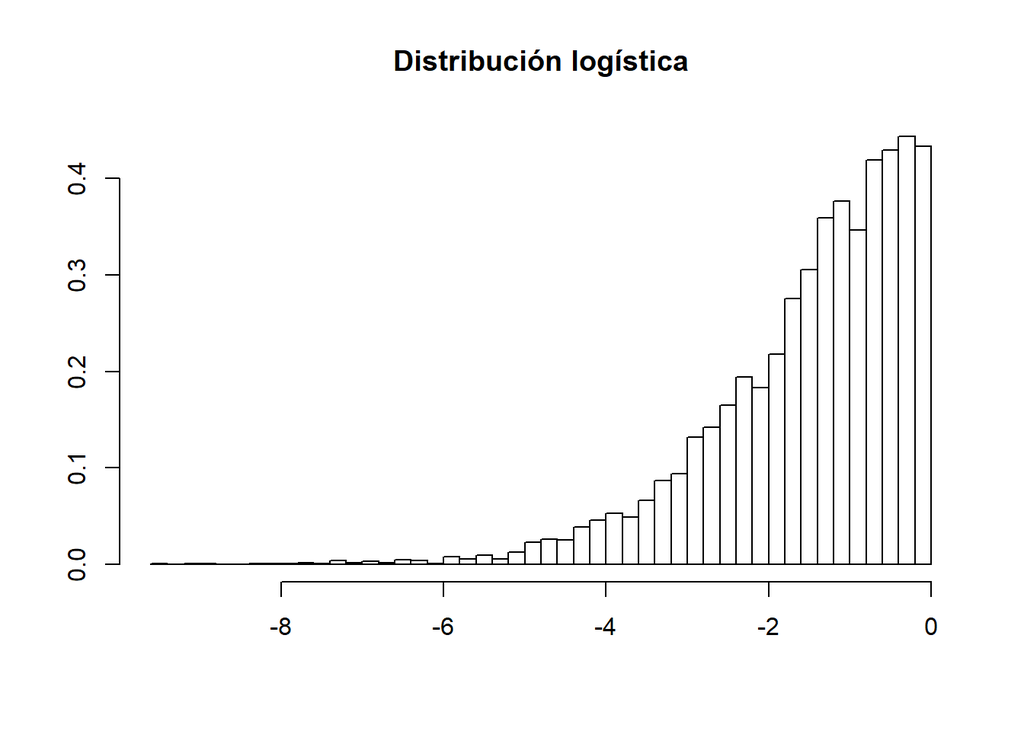

```r
Dist_logistica<-function(n,g,b){
u<-runif(n)
x<-g+b*(log(u)-1+u)
return(x)
}

hist(Dist_logistica(5000,0,1),probability =T,breaks=60,main = "Distribución logística",xlab = "",ylab = "")
```

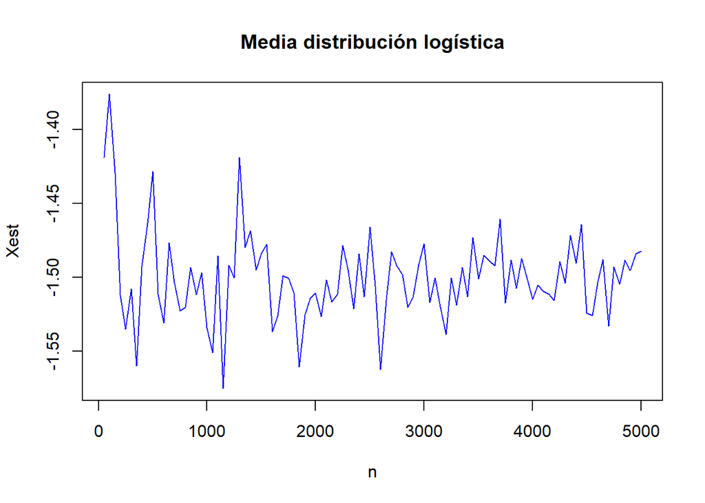

```r
n_s<-c(seq(50,5000,by=50))
X_est<-c()
for (i in 1:length(n_s)) {
  X_est[i]<-sum(Dist_logistica(n_s[i],0,1))/n_s[i]
}

plot(n_s[1:length(n_s)],X_est[1:length(n_s)],type = "l",col="blue", xlab = "n",ylab = "Xest",main="Media distribución logística")
```

*Pareto $f(x)=\frac{\alpha_2c^{\alpha_2}}{x^{\alpha_x+1}}; c>0,\alpha_2>0,x>c$.

$$F_X=\int_c^x\frac{\alpha_2c^{\alpha_2}}{s^{\alpha_x+1}}ds=\alpha_2c^{\alpha_2}\frac{s^{-\alpha_2}}{-\alpha_{2}}\Big|_{c}^{x}=1-(\frac{c}{x})^{\alpha_{2}}$$
.

$$F^{-1}(u)=\frac{c}{(1-u)^{\frac{1}{\alpha_2}}}$$

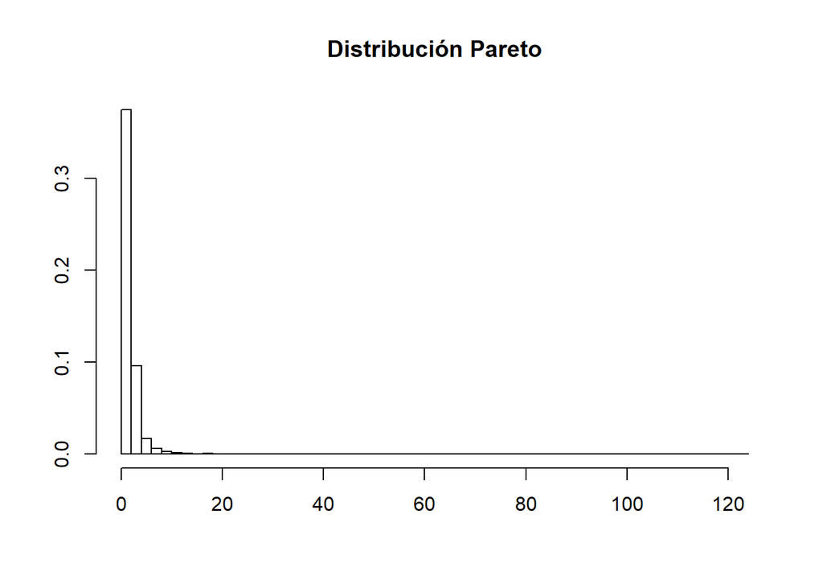

```r
S_pareto<-function(n,c,alfa){
  u<-runif(n)
  x<-c/(1-u)^(1/alfa)
  return(x)
}

hist(S_pareto(5000,1,2),probability =T,breaks=60,main = "Distribución Pareto",xlab = "",ylab = "")
```

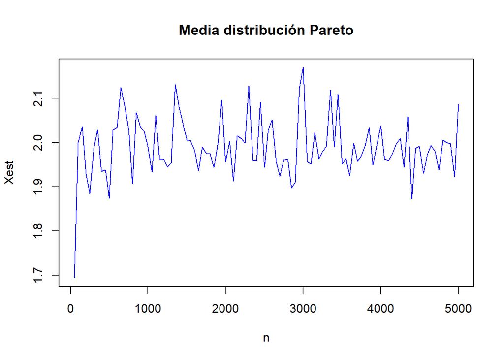

```r
n_s<-c(seq(50,5000,by=50))
X_est<-c()
for (i in 1:length(n_s)) {
  X_est[i]<-sum(S_pareto(n_s[i],1,2))/n_s[i]
}

plot(n_s[1:length(n_s)],X_est[1:length(n_s)],type = "l",col="blue", xlab = "n",ylab = "Xest", main="Media distribución Pareto")
```

# Problema 4

Grafiquen las siguientes densidades. Dar los algoritmos de transformación inversa, composición y aceptación-rechazo para cada una de las siguientes densidades. Discutir cuál algoritmo es preferible para cada densidad.

$$f(x)=\frac{3x^2}{2}I(x)_{[-1,1]}$$

$$f(x)=\begin{cases} 0,x\le0 \\ \frac{x}{a(1-a)}, 0\le x\le a\\ \frac{1}{1-a}, a\le x \le 1-a \\ \frac{1-x}{a(1-a)},1-a\le x \le 1\\ 0, x\ge 1 \end{cases}$$

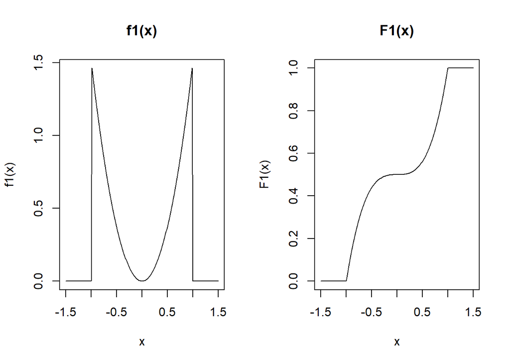

```r
ind<-function(x,a,b){
ifelse(x<=b & x>= a,1,0)
}

f1<-function(x){
(3*(x^2)/2)*ind(x,-1,1)
}

F1<-function(x){
ifelse(x<=-1,0,ifelse(x<=1,0.5*(x^3+1),1))
}

x<-seq(-1.5,1.5,length=200)
par(mfrow=c(1,2))
plot(x,f1(x),type="l",main="f1(x)")
plot(x,F1(x),type = "l",main = "F1(x)")
```

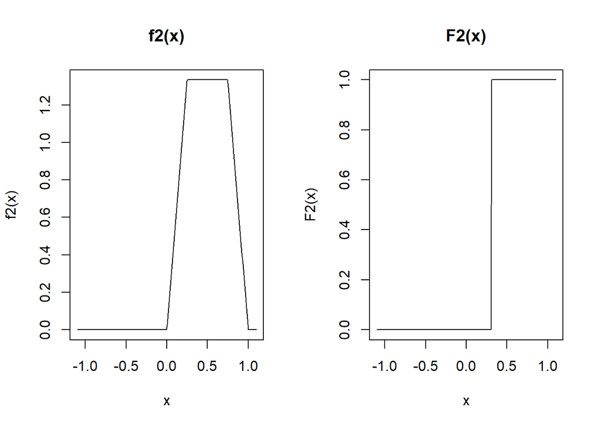

```r
f2<-function(x,a=0.25){
ind(x,-1,1)*(ind(x,0,a)*(x/(a*(1-a)))+ind(x,a,1-a)/(1-a)+ind(x,1-a,1)*((1-x)/(a*(1-a))))
}

F2<-function(x,a=0.25){
ind(x,0,a*x^2/(2*a*(1-a))+(x-a/2)/(1-a)*ind(x,a,1-a)+((1-3*a/2)/(1-a)+(x*(1-x/2)-(1-a)*(1+a)/2)/(a*(1-a)))*ind(x,1-a,1)+ind(x,1,100))
}

par(mfrow=c(1,2))
x<-seq(-1.1,1.1,length=200)
plot(x,f2(x),type="l",main="f2(x)")
plot(x,F2(x),type="l",main="F2(x)")
```

# Problema 5

Considerando la transformación polar de Marsaglia para generar muestras de normales estándar, muestren que la probabilidad de aceptación de $S=V_{1}^{2}+V_{2}^{2}$ en el paso 2 es $\frac{\pi}{4}$. Encuentre la distribución del número de rechazos de S antes de que ocurra una aceptación. ¿Cuál es el número esperado de ejecuciones del paso 1?

# Problema 6

Obtengan una muestra de 1,000 números de la siguiente distribución discreta, para $k=100$.
$$p(x)=\frac{2x}{k(k+1)}; x=1,2,...k$$

```r
x <-sample(1:100,size=1000,replace=T,prob=c(seq(1:100)*(2/10100)))
x[1:50]
```

```
##  [1]  98  26  99  96  82  63  87  98  52  64  58  57  98  62  62  95  76
## [18]  75  74  31  81  96  99  66  47  49  82  52  55  84  56  54  89  95
## [35]  75  61  39  66  54  99  77  47  22  11  97  86 100  48  64  35
```

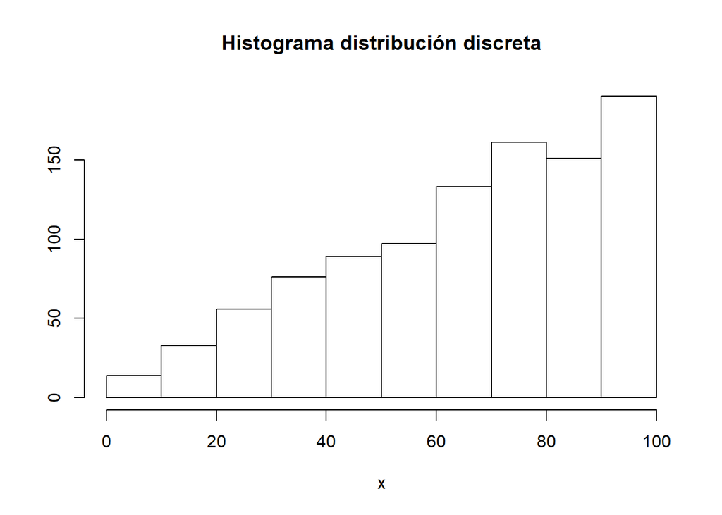

```r
hist(x,main = "Histograma distribución discreta",ylab = "")
```

# Problema 7

Desarrollen un algoritmo para generar una variable aleatoria binomial, usando la técnica de convolución (Hint: ¿cuál es la relación entre la distribución binomial y Bernoulli?). Generar una muestra de 100,000 números. ¿Qué método es más eficiente, el de convoluciones o la función rbinom en R?

```r
s_Binom<-function(n,t,p){
  esp_muestral<-c(0,1)
  muestra_Binom<-c()
  for (i in 1:n) {
  muestra_Binom[i]<-sum(sample(esp_muestral,t,replace = TRUE,prob = c(p,1-p)))
  }
  return(muestra_Binom)
}
```

```r
ptm <- proc.time()
prueba1<-s_Binom(1,100000,0.4)
proc.time()-ptm
```

```
##    user  system elapsed
##    0.02    0.00    0.01
```

```r
ptm<-proc.time()
prueba2<-rbinom(1,100000,0.4)
proc.time()-ptm
```

```
##    user  system elapsed
##    0.01    0.00    0.02
```

# Problema 8

Para un proceso Poisson no homogéneo con función de intensidad dada por:
$$\lambda(t)=\begin{cases}5,t\in(1,2],(3,4],(5,6]... \\3,t\in(0,1],(2,3],(4,5]...\end{cases}$$

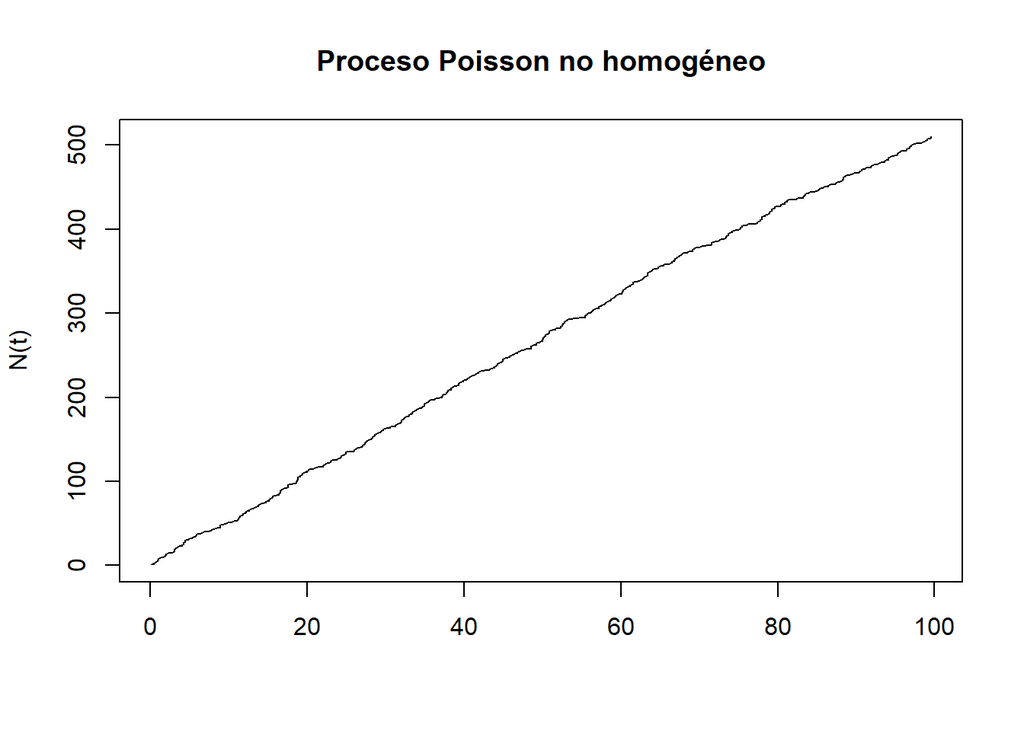

```
## [[1]]
##   [1]  0.0820192  0.4391209  0.4468845  0.7127479  0.7552288  0.9422980
##   [7]  0.9853946  1.0848485  1.2836573  1.6881311  1.8874780  1.9038924
##  [13]  2.0518820  2.0805655  2.2003369  2.8499541  3.0005814  3.0684670
##  [19]  3.0908013  3.1794110  3.3397563  3.5012935  3.5457857  4.0679117
##  [25]  4.0949888  4.2653664  4.2666202  4.4161442  4.4250443  4.4610263
##  [31]  4.8426796  4.9826222  5.3191415  5.4096044  5.7399344  5.8527445
##  [37]  5.9501987  6.3582087  6.5530169  6.8190204  7.4819312  7.7914020
##  [43]  7.8438060  8.1141556  8.4881989  8.9124559  8.9351487  8.9408088
##  [49]  9.3423526  9.6299628  9.8345129 10.3862565 10.6120053 11.0217062
##  [55] 11.1925863 11.2273046 11.3735656 11.4137586 11.4169252 11.7008707
##  [61] 11.8205004 11.8827856 12.1685986 12.1902104 12.2481447 12.6471215
##  [67] 12.7855145 13.0889737 13.3356462 13.4623805 13.8046221 13.8112653
##  [73] 13.8475993 14.0878157 14.4430018 14.7400817 15.1162608 15.1780106
##  [79] 15.2626047 15.3130122 15.5305655 15.5898505 15.6817531 15.9853173
```

[output cut: 103 more lines]

```r
lambdat<-function(t){
x<-paste("","{",0,"<=t & t<",1,"}",sep="")
for(i in seq(2,100,2)){
x<-paste(x,paste("","{",i,"<=t & t <",1+i,"}",sep=""),sep="|")
}
return(ifelse(eval(parse(text=0)),3,5))
}
poissonnohomogeneo<-function(lambdat,n,pic=T){
    lambda<-5
    TT<-rexp(n,lambda)
    s<-cumsum(TT)
    u<-runif(n)
    ss<-s[u<=lambdat(s)/lambda]
    Ns<-1:length(ss)
    if(pic==T){
    plot(ss,Ns,type="s",xlab="",ylab="N(t)",main="Proceso Poisson no homogéneo")
    return(list(ss,cuenta=Ns))
}
}
poissonnohomogeneo(lambdat,510)
```

# Problema 9

Simular un proceso Poisson no homogéneo con función de intensidad dada por $\lambda(t)=sin(t)$.

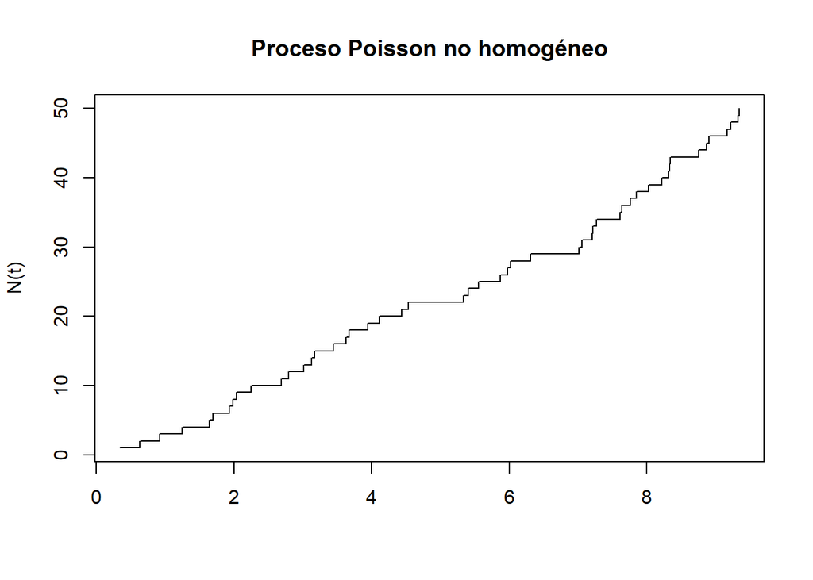

```
## [[1]]
##  [1] 0.3392479 0.6308763 0.9189420 1.2431212 1.6402907 1.6955887 1.9343538
##  [8] 1.9864544 2.0338078 2.2519441 2.6923185 2.7974513 3.0112884 3.1318536
## [15] 3.1761439 3.4436983 3.6318424 3.6736640 3.9469621 4.1171700 4.4393442
## [22] 4.5324190 5.3343072 5.4076375 5.5590253 5.8740867 5.9746307 6.0208271
## [29] 6.3105479 7.0115146 7.0573341 7.2077366 7.2159793 7.2674775 7.6101562
## [36] 7.6410062 7.7640262 7.8521552 8.0228663 8.2160785 8.3213856 8.3390416
## [43] 8.3447752 8.7526069 8.8673173 8.9065452 9.1702780 9.2223934 9.3241989
## [50] 9.3452737
##
## $cuenta
##  [1]  1  2  3  4  5  6  7  8  9 10 11 12 13 14 15 16 17 18 19 20 21 22 23
## [24] 24 25 26 27 28 29 30 31 32 33 34 35 36 37 38 39 40 41 42 43 44 45 46
## [47] 47 48 49 50
```

```r
lambdat2<-function(t){sin(t)}

poissonnohomogeneo2<-function(lambdat,n,pic=T){
    lambda<-1
    TT<-rexp(n,lambda)
    s<-cumsum(TT)
    u<-runif(n)
    ss<-s[u<=lambdat(s)/lambda]
    Ns<-1:length(ss)
    if(pic==T){
    plot(ss,Ns,type="s",xlab="",ylab="N(t)",main="Proceso Poisson no homogéneo")
    return(list(ss,cuenta=Ns))
}
}
poissonnohomogeneo(lambdat,50)
```

# Problema 10

Una compañía de seguros tiene 1000 asegurados, cada uno de los cuales presentará de manera independiente una reclamación en el siguiente mes con probabilidad $p=0.09245$. Suponiendo que las cantidades de los reclamos hechos son variables aleatorias normales con media 7000 y desviación estándar 5000, hagan simulación para estimar la probabilidad de que la suma de los reclamos exceda $500,000.

```r
comp_seguros<-function(n_as,p,m,de){
  n_rec<-sum(rbinom(n,1,p))
  montos_rec<-rnorm(n_rec,m,de)
  tot_rec<-sum(montos_rec)
}

registro<-replicate(10000,comp_seguros(1000,0.09245,7000,5000))
p_exceder<-length(subset(registro,registro>500000))/10000
p_exceder
```

```
## [1] 0.9712
```

# Problema 11

Escribir una función para generar una mezcla de una distribución normal multivariada con dos componentes con medias $ _1,_2$ y matrices de covarianzas $S_1,S_2$ respectivamente. Con el programa, generar una muestra de tamaño $n = 1000$ observaciones de una mezcla 50% de una normal 4-dimensional con $\mu_1 = (0,0,0,0), \mu_2 = (2,3,4,5)$, y matrices de covarianzas $S_1 = S_2 = I_4$. Obtener los histogramas de las 4 distribuciones marginales

```r
r_normal_multi <-function(n,mu,Sigma){
d <-length(mu)
S <-svd(Sigma)
Q <- S$u %*%diag(sqrt(S$d)) %*%t(S$v)
Z <-matrix(rnorm(n*d),nrow=n, ncol=d)
X <- Z %*% Q +matrix(mu,n,d,byrow=T)
X
}

Sigma <-matrix(c(1, 0, 0,0, 0, 1, 0, 0, 0,0,1,0,0,0,0,1),byrow=T,nrow=4)
n<-1000

Y1<-r_normal_multi(n,c(0,0,0,0),Sigma = Sigma)
Y2<-r_normal_multi(n,c(2,3,4,5),Sigma = Sigma)
u <-runif(n)
k <-as.integer(u > 0.5)
Y <- k*Y1 + (1-k)*Y2

head(Y)
```

```
##           [,1]        [,2]       [,3]      [,4]
## [1,]  2.087291  4.13987925  4.6483956 4.8421710
## [2,] -1.730851 -0.24935595  0.3881965 1.3786954
## [3,] -1.417851 -0.02709898 -0.1956776 0.4282698
## [4,]  3.508345  3.66384156  3.3257919 5.1356317
## [5,]  2.766940  4.08819019  3.4531237 5.3731732
## [6,]  2.503429  3.01723342  3.2706021 4.8206988
```

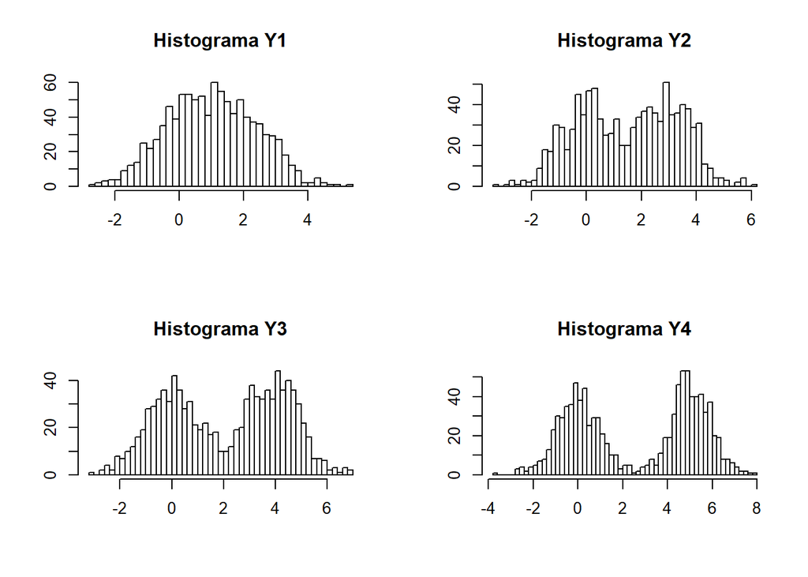

```r
par(mfrow=c(2,2))

hist(Y[,1],xlab = "",ylab = "",main = "Histograma Y1",breaks = 50)
hist(Y[,2],xlab = "",ylab = "",main = "Histograma Y2",breaks = 50)
hist(Y[,3],xlab = "",ylab = "",main = "Histograma Y3",breaks = 50)
hist(Y[,4],xlab = "",ylab = "",main = "Histograma Y4",breaks = 50)
```

# Problema 12

Distribución de Wishart. Suponer que $M = X^{T}X$, donde $X$ es una matrix de n x d de una muestra aleatoria de una distribución $N_d (\mu,Σ)$. Entonces $M$ tiene una distribución Wishart con matriz de escala $Σ$ y $n$ grados de libertad, y se denota $W\sim W_{d}(Σ,n)$. Cuando $d=1$, los elementos de $X$ son una muestra aleatoria de una $N(\mu,\sigma^2)$, por lo que $W_1(\sigma^2,n)\sim σ^2χ2$. Una forma de generar observaciones de una distribución Wishart, es generar muestras de multivariadas normales y calcular la matriz producto $XX^T$. Programar este método. Noten que este método es muy costoso porque se tienen que generar $nd$ valores aleatorios normales para determinar las $d(d + 1)/2$ diferentes entradas de $M$.

```r
Wishart_1<-function(n,mu,s){
  X<-r_normal_multi(n,mu,s)
  B<-X%*%t(X)
  return(B)

}

Wishart_ma<-function(tm,n,mu,s){
  replicate(tm,Wishart_1(n,mu,s))
}

#Ejemplo
ptm<-proc.time()
Wishart_ma(4,4,c(1,1),matrix(c(1, 0, 0,1),byrow=T,nrow=2))
```

```
## , , 1
##
##          [,1]      [,2]     [,3]     [,4]
## [1,] 5.152330  6.728210 2.772913 7.046570
## [2,] 6.728210 10.827328 3.221743 8.453591
## [3,] 2.772913  3.221743 1.570448 3.938728
## [4,] 7.046570  8.453591 3.938728 9.911489
##
## , , 2
##
##           [,1]      [,2]     [,3]      [,4]
## [1,] 0.9597006 1.0700087 0.104004 0.2123941
## [2,] 1.0700087 1.4264554 1.142968 0.7613976
## [3,] 0.1040040 1.1429680 4.529176 2.3307380
## [4,] 0.2123941 0.7613976 2.330738 1.2257763
##
## , , 3
##
##            [,1]       [,2]      [,3]       [,4]
## [1,] 11.5267688 -0.6930915 1.9620575 12.8058103
## [2,] -0.6930915  0.5949016 0.9764624 -0.4948058
## [3,]  1.9620575  0.9764624 2.4990851  2.7241822
## [4,] 12.8058103 -0.4948058 2.7241822 14.3636677
##
## , , 4
##
##            [,1]       [,2]      [,3]       [,4]
## [1,]  0.3088293 -0.5423022  1.645780  0.7633691
## [2,] -0.5423022  2.1598301 -3.193068 -0.5328606
## [3,]  1.6457800 -3.1930677  8.846589  3.8653592
## [4,]  0.7633691 -0.5328606  3.865359  2.4270379
```

```r
proc.time()-ptm
```

```
##    user  system elapsed
##       0       0       0
```

Un método más eﬁciente se basa en la descomposición de Bartlett: sea $T = (T_{ij})$ una matriz triangular inferior de d×d con entradas independientes que satisfacen: $T_{ij}\sim N(0,1)$ independientes para $i>j$, $T_{ii}\sim \sqrt{\chi_{n-i+1}^{2}}, i=1,..,d$. Entonces la matrix $A=TT^{'}$ tiene una distribución $W_d(I_d,n)$. Para generar variables $W_d(\Sigma,n)$, obtener la descomposición de Cholesky $\Sigma=LL^{'}$, donde $L$ es triangular inferior. Entonces $LAL^{'}\sim W_d(\Sigma,n)$.

# Problema 13

Las ocurrencias de huracanes que tocan tierra durante el fenómeno meteorológico “el Niño” se modelan como un proceso Poisson (ver Bove et al (1998)). Los autores aseguran que “durante un año del Niño, la probabilidad de dos o más huracanes haciendo contacto con tierra en los Estados Unidos es 28 %”. Encontrar la tasa del proceso Poisson.

# Problema 14

Comenzando a mediodía, los comensales llegan a un restaurante de acuerdo a un proceso Poisson a una tasa de 5 clientes por minuto. El tiempo que cada cliente pasa comiendo en el restaurante tiene una distribución exponencial con media de 40 minutos, independiente de otros clientes e independiente de los tiempos de arribo. Encuentra la distribución así como la media y varianza, del número de comensales en el restaurante a las 2:00pm. Simular el restaurante para verificar los resultados obtenidos.

# Problema 15